# Training a personal activity predictor

Jorge Monforte González

28 de julio de 2016

## Preparing the data

First we load the data from the files.

```r
training.base <- read.csv('pml-training.csv')
testing.base <- read.csv('pml-testing.csv')
```

We need to remove the columns that are filled with NAs. With this function we find them in the dataset.

```r
# This function lists the columns that are plenty of NA elements so they can be removed
get_na_columns <- function(df) {
  r <- NULL
  for (i in 1:ncol(df)) {
    c <- df[,i]
    if (all(is.na(c))) {
      r <- c(r, i)
    }
  }
  r
}
```

```r
# Remove spurious columns
div0_level <- "#DIV/0!"

# This function lists columns with div/0 entries to be removed
get_div0_columns <- function(df) {
  columns <- NULL
  for (cnum in seq(1,ncol(df))) {
    col <- df[,cnum]
    if (is.factor(col) & div0_level %in% levels(col))
      columns <- c(columns, cnum)
  }
  columns
}
```

We now use these functions to remove these columns and others in the beginning of the set that are mostly row metadata.

```r
metadata_columns <- 1:7
div_0_columns <- get_div0_columns(training.base)
testing_na_columns <- get_na_columns(testing.base)
problem_id_column <- 160

training.clean <- training.base[,-1*c(metadata_columns,
                                    div_0_columns, testing_na_columns)]
testing.clean <- testing.base[,-1*c(metadata_columns,
                                    div_0_columns, testing_na_columns, problem_id_column)]
```

Now that we have the training dataset clean we can extract the features and the outcomes in different objects to feed the algorithm.

```r
# The name of the colum where the target values are stored
classe_column <- which(names(training.clean) == 'classe')

features <- training.clean[,-classe_column]
outcomes<- training.clean[,classe_column]
```

## Random Forest model

We will first try to fit a random forest, for this we will use the k-fold partition method partitioning the data in 10 folds and using each of the folds once as **cross validation** set in each iteration.

```r
# We are splitting the data in 10 different folds
folds <- 10

set.seed(123)
seeds <- vector(mode="list", length=folds+1)
for(i in 1:folds) seeds[[i]] <- sample.int(floor(sqrt(ncol(features))))
seeds[[folds + 1]]<-sample.int(1000, 1)

tc <- trainControl(method="cv", repeats=1,seeds=seeds,index=createFolds(outcomes,k=folds))
library(doParallel)

cl <- makeCluster(detectCores())
registerDoParallel(cl)

fit <- train(outcomes ~ ., data=features, method="rf", trControl=tc)

stopCluster(cl)
```

After training the model returns a model fit with very low classification errors so we can keep this model and we dont need to train anything else different, as we can see in the confusion matrix.

```
##      A    B    C    D    E class.error
## A 5574    4    1    0    1 0.001075269
## B   20 3771    6    0    0 0.006847511
## C    0   10 3402   10    0 0.005844535
## D    0    0   22 3190    4 0.008084577
## E    0    2    4    7 3594 0.003604103
```

The model is fitted very fast and after the first 100 trees we cant see any improvement.

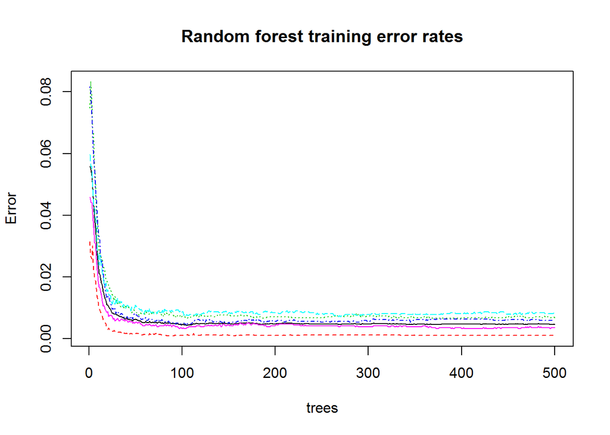

# Predict the provided testing data

With the model we can now predict the testing values and we get a 100% accuracy with these values.

| num | values |
| --- | --- |
| 1 | B |
| 2 | A |
| 3 | B |
| 4 | A |
| 5 | A |
| 6 | E |
| 7 | D |
| 8 | B |
| 9 | A |
| 10 | A |
| 11 | B |
| 12 | C |
| 13 | B |
| 14 | A |
| 15 | E |
| 16 | E |
| 17 | A |
| 18 | B |
| 19 | B |
| 20 | B |